# Act_report

### ACT REPORT

*A detailed report on all the acts taken to gather, wrangle, and analyze the twitter archive of WeRateDogs.*

The following packages (libraries) were imported to complete this project:

- pandas, numpy, requests, tweepy, json, matplotlib, seaborn, time, and WordCloud

#### Step 1: Gathering data

In this step, I gathered three pieces of data from various sources using different methods.

- The first data gathered is the WeRateDogs Twitter archive (a CSV file) which was downloaded manually through a given link. Then I used Pandas read_csv() method to read the data into a pandas DataFrame, stored as twitter_archive.
- The second data gathered is the tweet image predictions which is hosted on Udacity's servers and was downloaded programatically using the Requests library and a given URL.
- The third data gathered is an additional data from the Twitter API. I gathered each tweet's retweet count and favorite {'like') count. Using the tweet IDs in the WeRateDogs Twitter archive, I queried the Twitter API for each tweet's JSON data using Python's Tweepy library and stored each tweet's entire set of JSON data in a fille called tweet_json.txt. Then read this .txt file line by line into a pandas DataFrame.

#### Step 2: Assessing data

After gatherinng all three pieces of data, I assessed them visually and programmatically for quality and tidiness issues.

- To assess the data gathered visually, I displayed each piece of gathered data in the Jupyter notebook by calling the name used to save the DataFrame. (twitter_archive, df_image_pred, and df_json)
- To assess the data gathered programatically, I used Pandas DataFrame info() method to get information about each column of the DataFrame. I also use Pandas DataFrame describe() method to get the summary statistics for numerical values in the DataFrame

#### Step 3: Cleaning data

In this step, I cleaned all of the issues detected while assessing.

- Before cleaning, I made a copy of the original data.
- During cleaning, I used the define-code-test framework and clearly documented it.
- I merged individual pieces of data and stored it as cleaned_df which is a high-quality and tidy master pandas DataFrame

#### Step 4: Storing data

In this section, I stored the cleaned master DataFrame in a CSV file with the main one named twitter_archive_master.csv

#### Step 5: Analyzing and Visualizing Data

In this section, I analyzed and visualized the wrangled data. The following insights were produced:

- Logan has the highest rating of 75/10
- There is a strong positive relationship between the number of likes and the no of retweets for a tweet. That is, the higher the number of likes for a tweet, the higher the no of retweets, and vice versa.

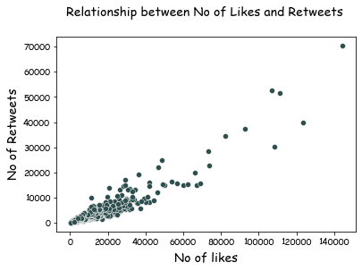

- The most common number of images posted in a tweet is 1.

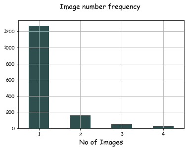

- The most common source of tweets is from iPhone devices which consists of over 90% of sources.

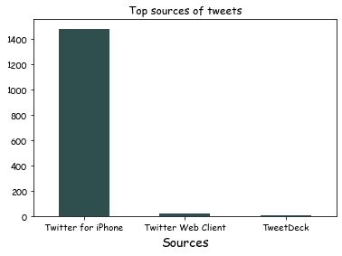

- The most common words used in texts are 'Meet', 'Say', 'Please', 'Oh', 'Guys', 'Everybody', 'let', among others.

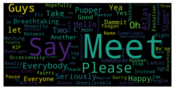

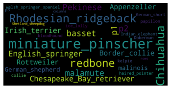